# assignment07

Author

Sarah Krause and Miguel Villa

# Set up

Read in the data and load libraries

```r
options(scipen = 999)

library(tidyverse)
library(here)
library(tidymodels)
library(skimr)
library(janitor)
library(corrplot)
library(tictoc)
library(vip)
library(e1071)
library(glmnet)

data <- read.csv(here("data/assignment_modeling.csv"))
```

## Split the data

```r
set.seed(20260412)
# Place 80% of the data in the training data
split <- initial_split(data, prop = 0.8)

# Obtain the training data
train_data <- training(split)
```

## EDA on the training data

### Basic Overview

```r
# Check Names
names(train_data)
```

```
  [1] "GIDTR"                            "State_name"
  [3] "County_name"                      "Num_BGs_in_Tract"
  [5] "LAND_AREA"                        "URBANIZED_AREA_POP_CEN_2010"
  [7] "URBAN_CLUSTER_POP_CEN_2010"       "RURAL_POP_CEN_2010"
  [9] "Tot_Population_CEN_2010"          "Tot_Population_ACS_13_17"
 [11] "Males_CEN_2010"                   "Males_ACS_13_17"
 [13] "Females_CEN_2010"                 "Females_ACS_13_17"
 [15] "Median_Age_ACS_13_17"             "Pop_under_5_CEN_2010"
 [17] "Pop_under_5_ACS_13_17"            "Pop_5_17_CEN_2010"
 [19] "Pop_5_17_ACS_13_17"               "Pop_18_24_CEN_2010"
 [21] "Pop_18_24_ACS_13_17"              "Pop_25_44_CEN_2010"
 [23] "Pop_25_44_ACS_13_17"              "Pop_45_64_CEN_2010"
 [25] "Pop_45_64_ACS_13_17"              "Pop_65plus_CEN_2010"
 [27] "Pop_65plus_ACS_13_17"             "Tot_GQ_CEN_2010"
 [29] "Inst_GQ_CEN_2010"                 "Non_Inst_GQ_CEN_2010"
```

[output cut: 131 more lines]

```r
# Glimpse the training data
glimpse(train_data)
```

```
Rows: 46,584
Columns: 292
$ GIDTR                            <dbl> 27039950500, 17097861108, 20131480200…
$ State_name                       <chr> "Minnesota", "Illinois", "Kansas", "T…
$ County_name                      <chr> "Dodge County", "Lake County", "Nemah…
$ Num_BGs_in_Tract                 <int> 3, 3, 4, 1, 4, 4, 2, 2, 4, 2, 2, 4, 3…
$ LAND_AREA                        <dbl> 7.251, 1.476, 270.596, 0.411, 1.512, …
$ URBANIZED_AREA_POP_CEN_2010      <int> 0, 6075, 0, 2053, 4144, 8008, 3691, 1…
$ URBAN_CLUSTER_POP_CEN_2010       <int> 5432, 0, 0, 0, 0, 0, 0, 0, 0, 0, 0, 0…
$ RURAL_POP_CEN_2010               <int> 222, 0, 4149, 0, 0, 72, 0, 0, 0, 0, 4…
$ Tot_Population_CEN_2010          <int> 5654, 6075, 4149, 2053, 4144, 8080, 3…
$ Tot_Population_ACS_13_17         <int> 5864, 5838, 4147, 2129, 4158, 8042, 3…
$ Males_CEN_2010                   <int> 2747, 2990, 2091, 956, 1978, 4017, 17…
$ Males_ACS_13_17                  <int> 2831, 2857, 2057, 1047, 1947, 3819, 1…
$ Females_CEN_2010                 <int> 2907, 3085, 2058, 1097, 2166, 4063, 1…
```

[output cut: 279 more lines]

```r
# We will have to remove the character variables: Aggregate_HH_INC_ACS_13_17, avg_Agg_HH_INC_ACS_13_17, Aggr_House_Value_ACS_13_17

# Check the structure
str(train_data)
```

```
'data.frame':   46584 obs. of  292 variables:
 $ GIDTR                           : num  27039950500 17097861108 20131480200 48201531400 6087121300 ...
 $ State_name                      : chr  "Minnesota" "Illinois" "Kansas" "Texas" ...
 $ County_name                     : chr  "Dodge County" "Lake County" "Nemaha County" "Harris County" ...
 $ Num_BGs_in_Tract                : int  3 3 4 1 4 4 2 2 4 2 ...
 $ LAND_AREA                       : num  7.251 1.476 270.596 0.411 1.512 ...
 $ URBANIZED_AREA_POP_CEN_2010     : int  0 6075 0 2053 4144 8008 3691 1602 5666 3514 ...
 $ URBAN_CLUSTER_POP_CEN_2010      : int  5432 0 0 0 0 0 0 0 0 0 ...
 $ RURAL_POP_CEN_2010              : int  222 0 4149 0 0 72 0 0 0 0 ...
 $ Tot_Population_CEN_2010         : int  5654 6075 4149 2053 4144 8080 3691 1602 5666 3514 ...
 $ Tot_Population_ACS_13_17        : int  5864 5838 4147 2129 4158 8042 3754 1650 5755 3970 ...
 $ Males_CEN_2010                  : int  2747 2990 2091 956 1978 4017 1772 846 2777 1822 ...
 $ Males_ACS_13_17                 : int  2831 2857 2057 1047 1947 3819 1768 872 2770 1907 ...
 $ Females_CEN_2010                : int  2907 3085 2058 1097 2166 4063 1919 756 2889 1692 ...
 $ Females_ACS_13_17               : int  3033 2981 2090 1082 2211 4223 1986 778 2985 2063 ...
```

[output cut: 86 more lines]

```r
# Examine missingness
tibble(variable = names(train_data),
       pct_missing = colMeans(is.na(train_data)) * 100) |>
  arrange(desc(pct_missing))
```

```
# A tibble: 292 × 2
   variable                         pct_missing
   <chr>                                  <dbl>
 1 pct_TEA_Update_Leave_CEN_2010          86.0
 2 pct_TEA_MailOutMailBack_CEN_2010        5.76
 3 Med_House_Value_ACS_13_17               3.11
 4 Aggr_House_Value_ACS_13_17              2.49
 5 avg_Agg_House_Value_ACS_13_17           2.49
 6 pct_Schl_Enroll_3_4_ACS_13_17           2.42
 7 Self_Response_Rate_ACS_13_17            1.66
 8 pct_No_Plumb_ACS_13_17                  1.43
 9 Low_Response_Score                      1.38
10 No_Plumb_ACS_13_17                      1.26
# ℹ 282 more rows
```

### Outcome Variable

```r
# Basic Distribution of non_return_rate
summary(train_data$non_return_rate)
```

```
   Min. 1st Qu.  Median    Mean 3rd Qu.    Max.
   0.00   15.70   20.30   21.31   25.80  100.00
```

```r
# Non Missing of non_return_rate
skim(train_data$non_return_rate)
```

Data summary

| Name | train_data$non_return_rat… |
| --- | --- |
| Number of rows | 46584 |
| Number of columns | 1 |
| _______________________ |  |
| Column type frequency: |  |
| numeric | 1 |
| ________________________ |  |
| Group variables | None |

**Variable type: numeric**

| skim_variable | n_missing | complete_rate | mean | sd | p0 | p25 | p50 | p75 | p100 | hist |
| --- | --- | --- | --- | --- | --- | --- | --- | --- | --- | --- |
| data | 0 | 1 | 21.31 | 7.89 | 0 | 15.7 | 20.3 | 25.8 | 100 | ▇▇▁▁▁ |

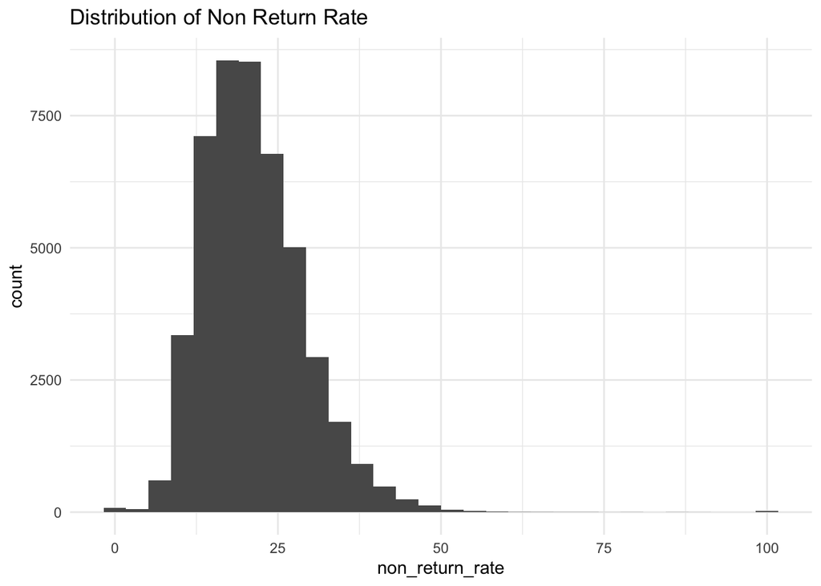

```r
# Examine the distribution of non_return_rate
train_data |>
  ggplot(aes(x = non_return_rate)) +
  geom_histogram() +
  theme_minimal() +
  labs(title = "Distribution of Non Return Rate") +
  theme_minimal()
```

```r
# State Frequency of non return rate
train_data |>
  group_by(State_name) |>
  summarize(average_non = mean(non_return_rate),
            count = n()) |>
  arrange(desc(average_non))
```

```
# A tibble: 52 × 3
   State_name               average_non count
   <chr>                          <dbl> <int>
 1 Puerto Rico Commonwealth        32.9   569
 2 Alaska                          27.5    86
 3 New Mexico                      26.9   298
 4 Louisiana                       26.7   723
 5 New York                        25.4  3041
 6 West Virginia                   24.6   308
 7 Hawaii                          24.4   212
 8 Oklahoma                        24.4   670
 9 Mississippi                     24.0   431
10 Nevada                          23.9   426
# ℹ 42 more rows
```

### Look for variables highly correlated with outcome variable

```r
# Get correlation of numeric predictors with outcome variable
correlations <- train_data |>
  select(where(is.numeric)) |>
  cor(use = "pairwise.complete.obs")

# Extract just the correlations with the outcome
outcome_cors <- correlations[, "non_return_rate"]

# Sort in order of highest correlations
outcome_cors_sorted <- sort(abs(outcome_cors), decreasing = TRUE)

# Keep only correlations of 0.5 or higher
outcome_cors_filtered <- outcome_cors_sorted[outcome_cors_sorted >= 0.5]

outcome_cors_filtered
```

```
              non_return_rate            Low_Response_Score
                    1.0000000                     0.7313594
 Self_Response_Rate_ACS_13_17  pct_Renter_Occp_HU_ACS_13_17
                    0.6793558                     0.6077478
  pct_Owner_Occp_HU_ACS_13_17   pct_Renter_Occp_HU_CEN_2010
                    0.6077477                     0.6027526
   pct_Owner_Occp_HU_CEN_2010  pct_NH_White_alone_ACS_13_17
                    0.6027526                     0.5982627
  pct_NH_White_alone_CEN_2010 pct_Prs_Blw_Pov_Lev_ACS_13_17
                    0.5938258                     0.5427130
    pct_Female_No_HB_CEN_2010  pct_Not_MrdCple_HHD_CEN_2010
                    0.5195485                     0.5166351
     pct_MrdCple_HHD_CEN_2010 pct_Not_MrdCple_HHD_ACS_13_17
                    0.5166350                     0.5157282
    pct_MrdCple_HHD_ACS_13_17      pct_Rel_Under_6_CEN_2010
                    0.5157280                     0.5156704
         Median_Age_ACS_13_17
                    0.5001333
```

Low_response_score and self_response_rate are very similar to our outcome variable. We will remove them to prevent data leakage. Many of the variables that are correlated with the outcome variable are related to the breakdown of renters and owners in an area, and the demographic breakdowns.

### Visualize the correlations

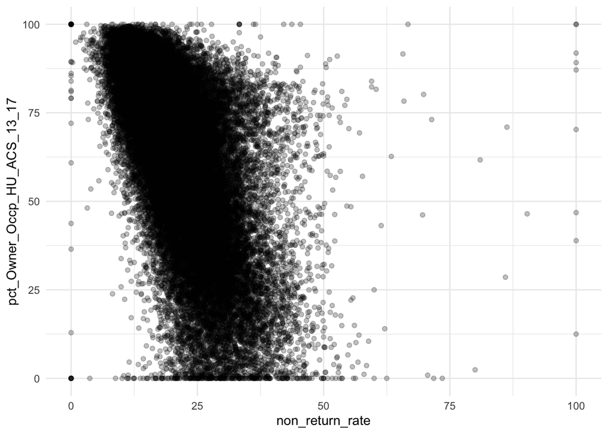

```r
# Percent owner occupied
train_data |>
  ggplot(aes(x = non_return_rate, y = pct_Owner_Occp_HU_ACS_13_17)) +
  geom_point(alpha = 0.25) +
  theme_minimal()
```

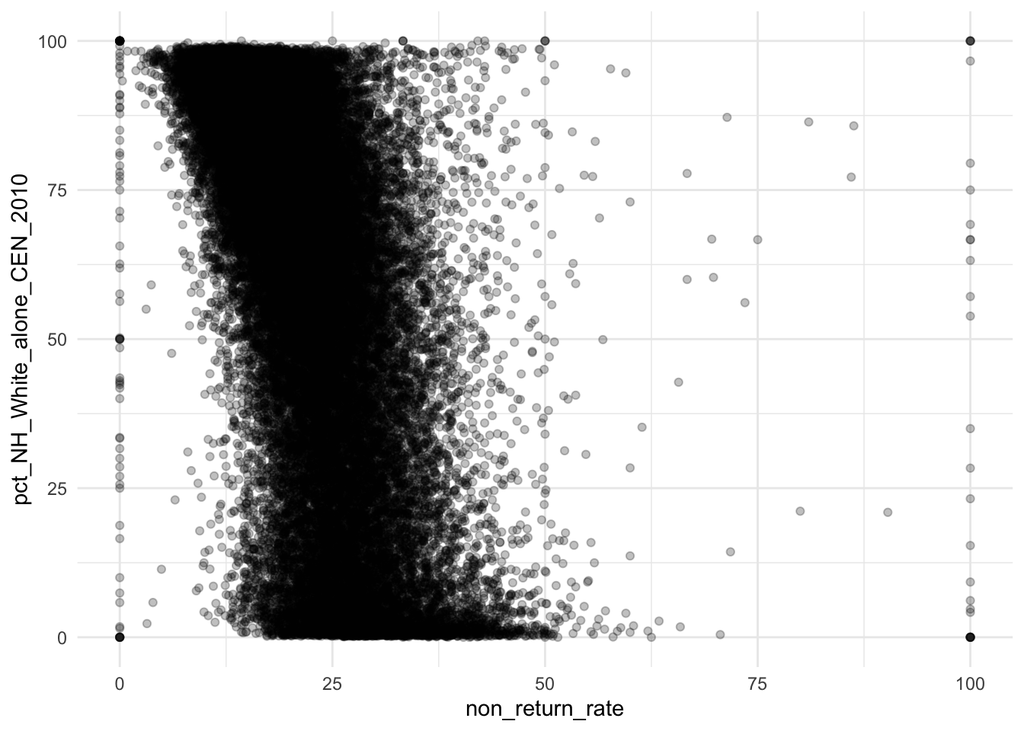

```r
# Percent white alone
train_data |>
  ggplot(aes(x = non_return_rate, y = pct_NH_White_alone_CEN_2010)) +
  geom_point(alpha = 0.25) +
  theme_minimal()
```

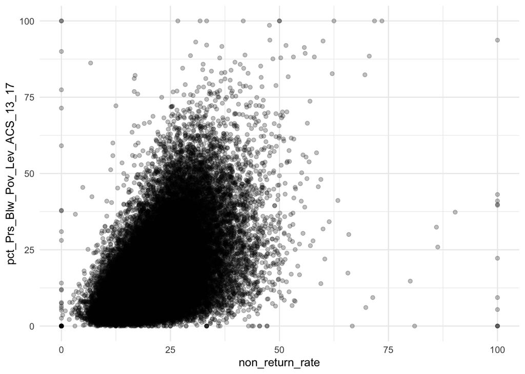

```r
# Percent below poverty level
train_data |>
  ggplot(aes(x = non_return_rate, y = pct_Prs_Blw_Pov_Lev_ACS_13_17)) +
  geom_point(alpha = 0.25) +
  theme_minimal()
```

### Transformations of non_return_rate

Here, we explore natural logarithm and logit transformations of non_return_rate.

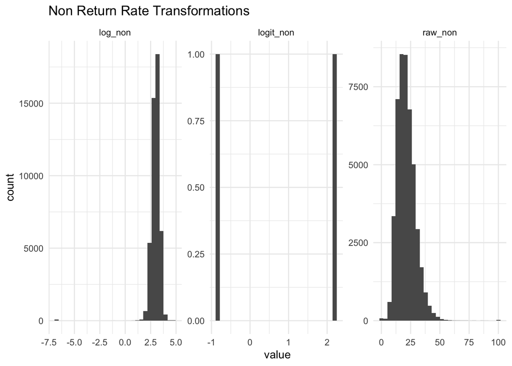

```r
train_data |>
  mutate(
    raw_non   = non_return_rate,
    log_non = log(non_return_rate + 0.001),
    logit_non = log(non_return_rate/ (1 - non_return_rate + 0.001))) |>
  pivot_longer(c(raw_non, log_non, logit_non)) |>
  ggplot(aes(x = value)) +
    geom_histogram() +
    facet_wrap(~name, scales = "free") +
    labs(title = "Non Return Rate Transformations") +
    theme_minimal()
```

There are also other variables, in particular the income, home value, and population variables which could benefit from a log.

The population variables are: Tot_Population_ACS_13_17, Males_ACS_13_17, Females_ACS_13_17, Pop_under_5_CEN_2010, Pop_18_24_CEN_2010 Value: Med_HHD_Inc_ACS_13_17, Med_House_Value_ACS_13_17 Otherss: pct_Age5p_French_ACS_13_17, pct_College_ACS_13_17, pct_Prs_Blw_Pov_Lev_ACS_13_17, pct_TwoPHealthIns_ACS_13_17, pct_Female_No_HB_CEN_2010, pct_Sngl_Prns_HHD_CEN_2010, pct_No_Plumb_ACS_13_17

### Correlations

Target Correlation: Typically you better features (non-target variables) that are highly correlated with target variables as they provide more predictive power.

```r
numeric_vars <- train_data |>
  select(where(is.numeric), -non_return_rate)

# find correlations
correlations <- cor(numeric_vars, train_data$non_return_rate, use = "complete.obs")

# Convert to dataframe and sort
non_cor <- data_frame(
  variable = rownames(correlations),
  correlation = (correlations)) |>
  arrange(desc(abs(correlation)))
non_cor
```

```
# A tibble: 285 × 2
   variable                      correlation[,1]
   <chr>                                   <dbl>
 1 Low_Response_Score                      0.667
 2 Self_Response_Rate_ACS_13_17           -0.629
 3 pct_NH_White_alone_CEN_2010            -0.623
 4 pct_NH_White_alone_ACS_13_17           -0.612
 5 pct_Female_No_HB_CEN_2010               0.578
 6 pct_Prs_Blw_Pov_Lev_ACS_13_17           0.522
 7 pct_Female_No_HB_ACS_13_17              0.506
 8 pct_Single_Unit_ACS_13_17              -0.498
 9 pct_Not_HS_Grad_ACS_13_17               0.479
10 pct_Owner_Occp_HU_CEN_2010             -0.475
# ℹ 275 more rows
```

One potential issue is a lot of these variables measure the same thing just in different survey (pct_NH_White_alone_CEN_2010, pct_NH_White_alone_ACS_13_17)

Feature Correlation: One potential issue can be when features are highly correlated with one another. As one example, the percentage of families that speak Tagalog and Spanish may both contribute similar information to our model. The inclusion of both can lead to overfitting and make our estimates less stable. This issue doesn’t matter as much for regularized models but does for regular regression.

Here, we examine correlation clusters.

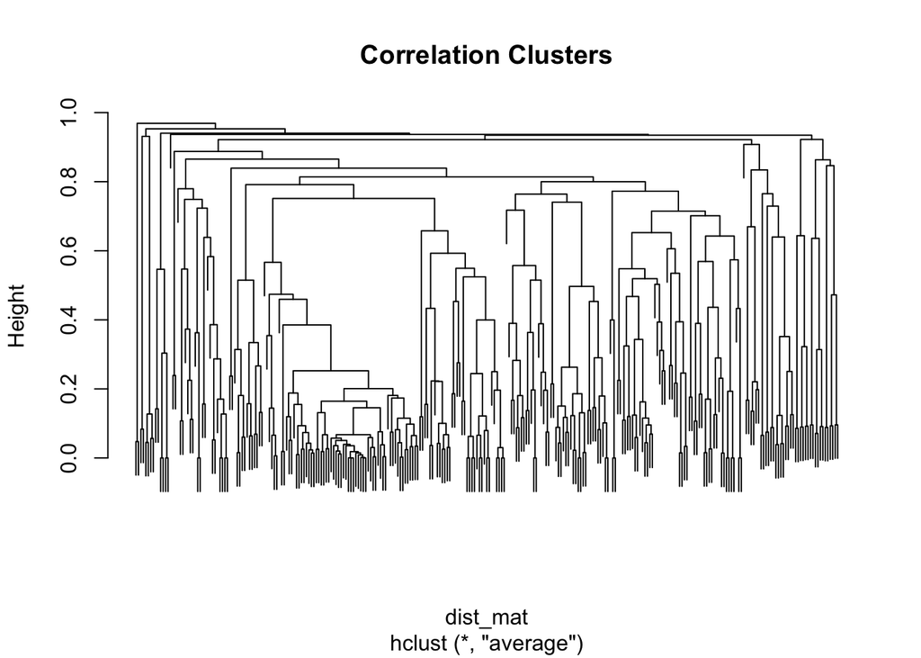

```r
corr_mat <- cor(numeric_vars, use = "pairwise.complete.obs")

# distance based
dist_mat <- as.dist(1 - abs(corr_mat))

# hierarchical clustering
hc <- hclust(dist_mat, method = "average")

plot(hc, labels = FALSE, main = "Correlation Clusters")
```

```r
# Id'ing cluster
clusters <- cutree(hc, h = 0.15)   # 1 - .85
table(clusters)
```

```
clusters
  1   2   3   4   5   6   7   8   9  10  11  12  13  14  15  16  17  18  19  20
  1   1   1   1   2   2  23   1   8   3   2  10   4   1   2   2   3   2   2   4
 21  22  23  24  25  26  27  28  29  30  31  32  33  34  35  36  37  38  39  40
  4   1   2   2   2   2   3   2   2   2   2   2   2   2   2   1   2   2   1   1
 41  42  43  44  45  46  47  48  49  50  51  52  53  54  55  56  57  58  59  60
  2   2   1   2   1   1   1   1   1   2   2   1   1   1   3   2   2   2   6   2
 61  62  63  64  65  66  67  68  69  70  71  72  73  74  75  76  77  78  79  80
  1   1   1   6   2   2   1   1   1   2   2   1   1   1   1   1   1   1   1   1
 81  82  83  84  85  86  87  88  89  90  91  92  93  94  95  96  97  98  99 100
  2   2   2   2   1   1   2   2   1   1   2   2   4   2   2   1   3   1   1   1
101 102 103 104 105 106 107 108 109 110 111 112 113 114 115 116 117 118 119 120
  1   2   1   1   2   2   2   2   2   1   1   1   3   1   1   1   5   6   4   2
121 122 123 124 125 126 127 128 129 130 131 132 133 134 135 136 137 138 139 140
  2   2   1   1   1   4   4   1   1   1   1   1   1   1   1   1   2   1   1   1
141
  1
```

```r
# Now we'll attach cluster numbers to each variable
cluster_df <- data.frame(
  variable = names(numeric_vars),
  cluster  = clusters)

representatives <- cluster_df |>
  group_by(cluster) |>
  slice(1) |>
  pull(variable)

vars_to_drop <- setdiff(cluster_df$variable, representatives)

vars_to_drop
```

```
  [1] "Tot_Population_ACS_13_17"       "Males_CEN_2010"
  [3] "Males_ACS_13_17"                "Females_CEN_2010"
  [5] "Females_ACS_13_17"              "Pop_5_17_CEN_2010"
  [7] "Pop_5_17_ACS_13_17"             "Pop_18_24_ACS_13_17"
  [9] "Pop_25_44_CEN_2010"             "Pop_25_44_ACS_13_17"
 [11] "Pop_45_64_ACS_13_17"            "Pop_65plus_ACS_13_17"
 [13] "Hispanic_ACS_13_17"             "NH_White_alone_ACS_13_17"
 [15] "NH_Blk_alone_ACS_13_17"         "NH_AIAN_alone_ACS_13_17"
 [17] "NH_Asian_alone_ACS_13_17"       "Pop_5yrs_Over_ACS_13_17"
 [19] "Othr_Lang_ACS_13_17"            "Pop_25yrs_Over_ACS_13_17"
 [21] "Pov_Univ_ACS_13_17"             "One_Health_Ins_ACS_13_17"
 [23] "Two_Plus_Health_Ins_ACS_13_17"  "Civ_labor_16plus_ACS_13_17"
 [25] "Civ_emp_16plus_ACS_13_17"       "Civ_emp_16_24_ACS_13_17"
 [27] "Civ_labor_25_44_ACS_13_17"      "Civ_emp_25_44_ACS_13_17"
 [29] "Civ_labor_45_64_ACS_13_17"      "Civ_emp_45_64_ACS_13_17"
```

[output cut: 57 more lines]

## Set up cross-validation and parallelization

```r
# 5 fold cross-validation
folds <- vfold_cv(train_data, v = 5)
```

```r
# Set up parallelization
library(doParallel)
cl <- makePSOCKcluster(parallel::detectCores() - 1)
registerDoParallel(cl)
```

# Predictive Modeling

## Model 1: Parametric

### Plain Vanilla Linear Regression

First, we try a “plain vanilla” linear regression model without removing the redundant variables we identified earlier. We remove character variables, variables that are similarly defined as our outcome variable, and a variable with a very high level of missingness. We use median imputation for the rest of the variables with missingness.

```r
set.seed(20260412)

# Recipe
model1_rec <- recipe(non_return_rate ~ ., train_data) |>
  # Specify and remove id variables
  update_role(State_name, County_name,
              new_role = "id") |>
  # Remove other variables
  step_rm(has_role("id"),
          # Remove character variables
          Aggr_House_Value_ACS_13_17,
          avg_Agg_HH_INC_ACS_13_17,
          avg_Agg_House_Value_ACS_13_17,
          Aggregate_HH_INC_ACS_13_17,
          # Remove variables similar to the outcome variable
          Self_Response_Rate_ACS_13_17,
          Low_Response_Score,
          # Remove variable with high missingness
          pct_TEA_Update_Leave_CEN_2010) |>
  # Median imputation for other variables with missingness
  step_impute_median(all_numeric_predictors())

prep(model1_rec) |> juice() |> names()
```

```
  [1] "GIDTR"                            "Num_BGs_in_Tract"
  [3] "LAND_AREA"                        "URBANIZED_AREA_POP_CEN_2010"
  [5] "URBAN_CLUSTER_POP_CEN_2010"       "RURAL_POP_CEN_2010"
  [7] "Tot_Population_CEN_2010"          "Tot_Population_ACS_13_17"
  [9] "Males_CEN_2010"                   "Males_ACS_13_17"
 [11] "Females_CEN_2010"                 "Females_ACS_13_17"
 [13] "Median_Age_ACS_13_17"             "Pop_under_5_CEN_2010"
 [15] "Pop_under_5_ACS_13_17"            "Pop_5_17_CEN_2010"
 [17] "Pop_5_17_ACS_13_17"               "Pop_18_24_CEN_2010"
 [19] "Pop_18_24_ACS_13_17"              "Pop_25_44_CEN_2010"
 [21] "Pop_25_44_ACS_13_17"              "Pop_45_64_CEN_2010"
 [23] "Pop_45_64_ACS_13_17"              "Pop_65plus_CEN_2010"
 [25] "Pop_65plus_ACS_13_17"             "Tot_GQ_CEN_2010"
 [27] "Inst_GQ_CEN_2010"                 "Non_Inst_GQ_CEN_2010"
 [29] "Hispanic_CEN_2010"                "Hispanic_ACS_13_17"
```

[output cut: 127 more lines]

```r
model0_mod <- linear_reg() |>
  set_mode(mode = "regression") |>
  set_engine(engine = "lm")

model0_wf <- workflow() |>
  add_recipe(model1_rec) |>
  add_model(model0_mod)

model0_resamples <- model0_wf |>
  fit_resamples(resamples = folds)
```

```
→ A | warning: prediction from rank-deficient fit; consider predict(., rankdeficient="NA")
```

```
There were issues with some computations   A: x1
```

[output not shown]

[output not shown]

[output not shown]

[output not shown]

```r
model0_resamples |>
  collect_metrics()
```

```
# A tibble: 2 × 6
  .metric .estimator  mean     n std_err .config
  <chr>   <chr>      <dbl> <int>   <dbl> <chr>
1 rmse    standard   4.71      5 0.0696  pre0_mod0_post0
2 rsq     standard   0.644     5 0.00814 pre0_mod0_post0
```

Next, we extract the 20 most important predictor variables from our linear regression model.

```r
# Variable importance
model0_final <- model0_wf |>
  last_fit(split)
```

```
→ A | warning: prediction from rank-deficient fit; consider predict(., rankdeficient="NA")
```

```
There were issues with some computations   A: x1
There were issues with some computations   A: x1
```

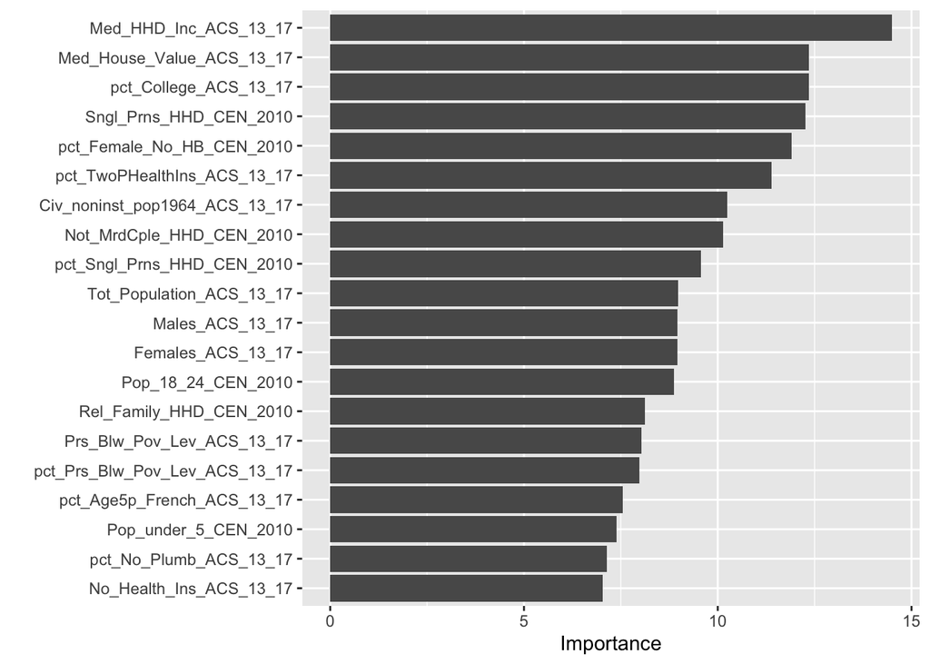

```r
model0_final |>
  extract_fit_parsnip() |>
  vip(num_features = 20)
```

```r
#Extracting the most important for later use
fit <- model0_final |>
  extract_fit_parsnip()

imp_tbl <- vi(fit)

# sort by absolute importance
imp_tbl <- imp_tbl |> arrange(desc(abs(Importance)))

# convert to a vector of variable names
top_vars <- imp_tbl$Variable[1:20]

top_vars
```

```
 [1] "Med_HHD_Inc_ACS_13_17"         "Med_House_Value_ACS_13_17"
 [3] "pct_College_ACS_13_17"         "Sngl_Prns_HHD_CEN_2010"
 [5] "pct_Female_No_HB_CEN_2010"     "pct_TwoPHealthIns_ACS_13_17"
 [7] "Civ_noninst_pop1964_ACS_13_17" "Not_MrdCple_HHD_CEN_2010"
 [9] "pct_Sngl_Prns_HHD_CEN_2010"    "Tot_Population_ACS_13_17"
[11] "Males_ACS_13_17"               "Females_ACS_13_17"
[13] "Pop_18_24_CEN_2010"            "Rel_Family_HHD_CEN_2010"
[15] "Prs_Blw_Pov_Lev_ACS_13_17"     "pct_Prs_Blw_Pov_Lev_ACS_13_17"
[17] "pct_Age5p_French_ACS_13_17"    "Pop_under_5_CEN_2010"
[19] "pct_No_Plumb_ACS_13_17"        "No_Health_Ins_ACS_13_17"
```

```r
top_vars_clean <- intersect(top_vars, names(train_data))
```

### Linear regression, removing redundant features

```r
set.seed(20260412)

# Recipe
model1_rec <- recipe(non_return_rate ~ ., train_data) |>
    # Specify and remove id variables
  update_role(State_name, County_name,
              new_role = "id") |>
  # Remove other variables
  step_rm(has_role("id"),
          # Remove character variables
          Aggr_House_Value_ACS_13_17,
          avg_Agg_HH_INC_ACS_13_17,
          avg_Agg_House_Value_ACS_13_17,
          Aggregate_HH_INC_ACS_13_17,
          # Remove variables similar to the outcome variable
          Self_Response_Rate_ACS_13_17,
          Low_Response_Score) |>
  # Remove redundant/highly correlated predictors
  step_rm(all_of(vars_to_drop)) |>
  # Median imputation for other variables with missingness
  step_impute_median(all_numeric_predictors())

prep(model1_rec) |>
  juice() |>
  names()
```

```
  [1] "GIDTR"                            "Num_BGs_in_Tract"
  [3] "LAND_AREA"                        "URBANIZED_AREA_POP_CEN_2010"
  [5] "URBAN_CLUSTER_POP_CEN_2010"       "RURAL_POP_CEN_2010"
  [7] "Tot_Population_CEN_2010"          "Median_Age_ACS_13_17"
  [9] "Pop_under_5_CEN_2010"             "Pop_under_5_ACS_13_17"
 [11] "Pop_18_24_CEN_2010"               "Pop_45_64_CEN_2010"
 [13] "Pop_65plus_CEN_2010"              "Tot_GQ_CEN_2010"
 [15] "Inst_GQ_CEN_2010"                 "Non_Inst_GQ_CEN_2010"
 [17] "Hispanic_CEN_2010"                "NH_White_alone_CEN_2010"
 [19] "NH_Blk_alone_CEN_2010"            "NH_AIAN_alone_CEN_2010"
 [21] "NH_Asian_alone_CEN_2010"          "NH_NHOPI_alone_CEN_2010"
 [23] "NH_NHOPI_alone_ACS_13_17"         "NH_SOR_alone_CEN_2010"
 [25] "NH_SOR_alone_ACS_13_17"           "Age5p_Only_English_ACS_13_17"
 [27] "Age5p_Spanish_ACS_13_17"          "Age5p_French_ACS_13_17"
 [29] "Age5p_German_ACS_13_17"           "Age5p_Russian_ACS_13_17"
```

[output cut: 55 more lines]

```r
model0_mod <- linear_reg() |>
  set_mode(mode = "regression") |>
  set_engine(engine = "lm")

model0_wf <- workflow() |>
  add_recipe(model1_rec) |>
  add_model(model0_mod)

model0_resamples <- model0_wf |>
  fit_resamples(resamples = folds)
```

```
→ A | warning: prediction from rank-deficient fit; consider predict(., rankdeficient="NA")
```

```
There were issues with some computations   A: x1
```

[output not shown]

[output not shown]

[output not shown]

```r
model0_resamples |>
  collect_metrics()
```

```
# A tibble: 2 × 6
  .metric .estimator  mean     n std_err .config
  <chr>   <chr>      <dbl> <int>   <dbl> <chr>
1 rmse    standard   4.72      5 0.0772  pre0_mod0_post0
2 rsq     standard   0.642     5 0.00759 pre0_mod0_post0
```

Removing redundant variables did not change the RMSE.

### Linear regression model with transformations

Next, we try a third linear regression model, with the only change from the previous model being that we apply natural logarithmic transformations of the following variables:

- Tot_Population_ACS_13_17, Males_ACS_13_17, Females_ACS_13_17
- Med_HHD_Inc_ACS_13_17, Med_House_Value_ACS_13_17
- pct_Age5p_French_ACS_13_17, pct_College_ACS_13_17, pct_Prs_Blw_Pov_Lev_ACS_13_17, pct_TwoPHealthIns_ACS_13_17, pct_Female_No_HB_CEN_2010, pct_Sngl_Prns_HHD_CEN_2010, pct_No_Plumb_ACS_13_17

We also normalize all predictors.

```r
set.seed(20260412)

# Recipe
model1_rec <- recipe(non_return_rate ~ ., train_data) |>
  # Specify and remove id variables
  update_role(State_name, County_name,
              new_role = "id") |>
  # Remove other variables
  step_rm(has_role("id"),
          # Remove character variables
          Aggr_House_Value_ACS_13_17,
          avg_Agg_HH_INC_ACS_13_17,
          avg_Agg_House_Value_ACS_13_17,
          Aggregate_HH_INC_ACS_13_17,
          # Remove variables similar to the outcome variable
          Self_Response_Rate_ACS_13_17,
          Low_Response_Score) |>
  # Apply log transformations
  step_log(Tot_Population_ACS_13_17, Males_ACS_13_17, Females_ACS_13_17, offset = 1) |>
  step_log(Med_HHD_Inc_ACS_13_17, Med_House_Value_ACS_13_17, offset = 1) |>
  step_log(pct_Age5p_French_ACS_13_17, pct_College_ACS_13_17,
           pct_Prs_Blw_Pov_Lev_ACS_13_17, pct_TwoPHealthIns_ACS_13_17,
           pct_Female_No_HB_CEN_2010, pct_Sngl_Prns_HHD_CEN_2010,
           pct_No_Plumb_ACS_13_17, offset = 1e-6) |>
  # Remove redundant/highly correlated predictors
  step_rm(all_of(vars_to_drop)) |>
  # Impute with median for numeric predictors' missing values
  step_impute_median(all_numeric_predictors()) |>
  # Normalize all predictors
  step_normalize(all_numeric_predictors())

prep(model1_rec) |> juice() |> names()
```

```
  [1] "GIDTR"                            "Num_BGs_in_Tract"
  [3] "LAND_AREA"                        "URBANIZED_AREA_POP_CEN_2010"
  [5] "URBAN_CLUSTER_POP_CEN_2010"       "RURAL_POP_CEN_2010"
  [7] "Tot_Population_CEN_2010"          "Median_Age_ACS_13_17"
  [9] "Pop_under_5_CEN_2010"             "Pop_under_5_ACS_13_17"
 [11] "Pop_18_24_CEN_2010"               "Pop_45_64_CEN_2010"
 [13] "Pop_65plus_CEN_2010"              "Tot_GQ_CEN_2010"
 [15] "Inst_GQ_CEN_2010"                 "Non_Inst_GQ_CEN_2010"
 [17] "Hispanic_CEN_2010"                "NH_White_alone_CEN_2010"
 [19] "NH_Blk_alone_CEN_2010"            "NH_AIAN_alone_CEN_2010"
 [21] "NH_Asian_alone_CEN_2010"          "NH_NHOPI_alone_CEN_2010"
 [23] "NH_NHOPI_alone_ACS_13_17"         "NH_SOR_alone_CEN_2010"
 [25] "NH_SOR_alone_ACS_13_17"           "Age5p_Only_English_ACS_13_17"
 [27] "Age5p_Spanish_ACS_13_17"          "Age5p_French_ACS_13_17"
 [29] "Age5p_German_ACS_13_17"           "Age5p_Russian_ACS_13_17"
```

[output cut: 55 more lines]

```r
model0_mod <- linear_reg() |>
  set_mode(mode = "regression") |>
  set_engine(engine = "lm")

model0_wf <- workflow() |>
  add_recipe(model1_rec) |>
  add_model(model0_mod)

model0_resamples <- model0_wf |>
  fit_resamples(resamples = folds)
```

```
→ A | warning: prediction from rank-deficient fit; consider predict(., rankdeficient="NA")
```

```
There were issues with some computations   A: x1
```

[output not shown]

[output not shown]

[output not shown]

```r
model0_resamples |>
  collect_metrics()
```

```
# A tibble: 2 × 6
  .metric .estimator  mean     n std_err .config
  <chr>   <chr>      <dbl> <int>   <dbl> <chr>
1 rmse    standard   4.76      5 0.0712  pre0_mod0_post0
2 rsq     standard   0.635     5 0.00803 pre0_mod0_post0
```

```r
model0_final <- model0_wf |>
  last_fit(split) |>
  collect_metrics()
```

```
→ A | warning: prediction from rank-deficient fit; consider predict(., rankdeficient="NA")
```

```
There were issues with some computations   A: x1
There were issues with some computations   A: x1
```

Applying log transformations did not improve the RMSE.

### Linear Regression with PCA hyperparameter tuning

Given the large number of variables in this dataset, we apply a principal component analysis (PCA) tuning grid. PCA can be especially helpful for this task because it handles multicollinearity, reduces overfitting, and reduces the number of predictors, which saves computational expense. Our tuning grid tunes over a range of 50 to 150 principal components.

```r
set.seed(20260412)

# Recipe
model1_rec <- recipe(non_return_rate ~ ., train_data) |>
  # Specify and remove id variables
  update_role(State_name, County_name,
              new_role = "id") |>
  step_rm(has_role("id"),
          # Remove variable with high missingness
          pct_TEA_Update_Leave_CEN_2010,
          # Remove character variables
          Aggr_House_Value_ACS_13_17,
          avg_Agg_HH_INC_ACS_13_17,
          avg_Agg_House_Value_ACS_13_17,
          Aggregate_HH_INC_ACS_13_17,
          # Remove variables similar to the outcome variable
          Self_Response_Rate_ACS_13_17,
          Low_Response_Score) |>
  # Impute median for numeric predictors
  step_impute_median(all_numeric_predictors()) |>
  # Normalize all predictors
  step_normalize(all_numeric_predictors()) |>
  # Apply PCA hyperparameter tuning
  step_pca(all_numeric_predictors(), num_comp = tune::tune())

model0_mod <- linear_reg() |>
  set_mode(mode = "regression") |>
  set_engine(engine = "lm")

model0_wf <- workflow() |>
  add_recipe(model1_rec) |>
  add_model(model0_mod)

# Add PCA grid
pca_grid <- grid_regular(
  num_comp(range = c(50, 150)),
  levels = 10)

model0_resamples <- tune_grid(
  model0_wf,
  resamples = folds,
  grid = pca_grid)

model0_resamples |>
  collect_metrics()
```

```
# A tibble: 20 × 7
   num_comp .metric .estimator  mean     n std_err .config
      <int> <chr>   <chr>      <dbl> <int>   <dbl> <chr>
 1       50 rmse    standard   4.92      5 0.0897  pre01_mod0_post0
 2       50 rsq     standard   0.611     5 0.00891 pre01_mod0_post0
 3       61 rmse    standard   4.86      5 0.0775  pre02_mod0_post0
 4       61 rsq     standard   0.620     5 0.00721 pre02_mod0_post0
 5       72 rmse    standard   4.83      5 0.0753  pre03_mod0_post0
 6       72 rsq     standard   0.624     5 0.00716 pre03_mod0_post0
 7       83 rmse    standard   4.82      5 0.0748  pre04_mod0_post0
 8       83 rsq     standard   0.627     5 0.00737 pre04_mod0_post0
 9       94 rmse    standard   4.79      5 0.0747  pre05_mod0_post0
10       94 rsq     standard   0.632     5 0.00729 pre05_mod0_post0
11      105 rmse    standard   4.76      5 0.0757  pre06_mod0_post0
12      105 rsq     standard   0.636     5 0.00742 pre06_mod0_post0
13      116 rmse    standard   4.74      5 0.0723  pre07_mod0_post0
14      116 rsq     standard   0.640     5 0.00687 pre07_mod0_post0
15      127 rmse    standard   4.72      5 0.0726  pre08_mod0_post0
16      127 rsq     standard   0.641     5 0.00707 pre08_mod0_post0
17      138 rmse    standard   4.72      5 0.0713  pre09_mod0_post0
18      138 rsq     standard   0.643     5 0.00680 pre09_mod0_post0
19      150 rmse    standard   4.71      5 0.0739  pre10_mod0_post0
20      150 rsq     standard   0.644     5 0.00723 pre10_mod0_post0
```

Our RMSE remains high for the levels of PCA tried in the grid.

### Elastic Net

Next, we try applying elastic net regularization with hyperparameter tuning for both the penalty and the mixture. Our motivation is to try to improve the linear regression model’s generalization to unseen data.

```r
set.seed(20260412)

# Recipe
en_rec <- recipe(non_return_rate ~ ., train_data) |>
  # Specify and remove id variables
  update_role(State_name, County_name,
              new_role = "id") |>
  step_rm(has_role("id"),
          # Remove variable with high missingness
          pct_TEA_Update_Leave_CEN_2010,
          # Remove character variables
          Aggr_House_Value_ACS_13_17,
          avg_Agg_HH_INC_ACS_13_17,
          avg_Agg_House_Value_ACS_13_17,
          Aggregate_HH_INC_ACS_13_17,
          # Remove variables similar to the outcome variable
          Self_Response_Rate_ACS_13_17,
          Low_Response_Score) |>
  # Impute median for numeric predictors
  step_impute_median(all_numeric_predictors()) |>
  # Normalize all predictors
  step_normalize(all_numeric_predictors())

# Mode
en_mode <- linear_reg(penalty = tune(), mixture = tune()) |> # works best for many variables
  set_mode(mode = "regression") |>
  set_engine(engine = "glmnet")

# Workflow
en_wf <- workflow() |>
  add_recipe(en_rec) |>
  add_model(en_mode)

# Resamples
en_grid <- grid_regular(
  penalty(),
  mixture(),
  levels = 20
)

# Tuning grid
en_tuning <- tune_grid(
  en_wf,
  resamples = folds,
  grid = en_grid
)

show_best(en_tuning)
```

```
# A tibble: 5 × 8
  penalty mixture .metric .estimator  mean     n std_err .config
    <dbl>   <dbl> <chr>   <chr>      <dbl> <int>   <dbl> <chr>
1 0.00785   0.632 rmse    standard    4.68     5  0.0776 pre0_mod313_post0
2 0.00785   0.579 rmse    standard    4.68     5  0.0776 pre0_mod312_post0
3 0.00785   0.737 rmse    standard    4.68     5  0.0772 pre0_mod315_post0
4 0.00785   0.684 rmse    standard    4.68     5  0.0774 pre0_mod314_post0
5 0.00785   0.526 rmse    standard    4.68     5  0.0777 pre0_mod311_post0
```

```r
# Finalize workflow
en_best <- select_best(en_tuning, metric = "rmse")

en_final_wf <- finalize_workflow(
  en_wf,
  en_best)
```

We do see a slight improvement in our RMSE by using elastic net regression. Next, we extract the top 50 most important predictors.

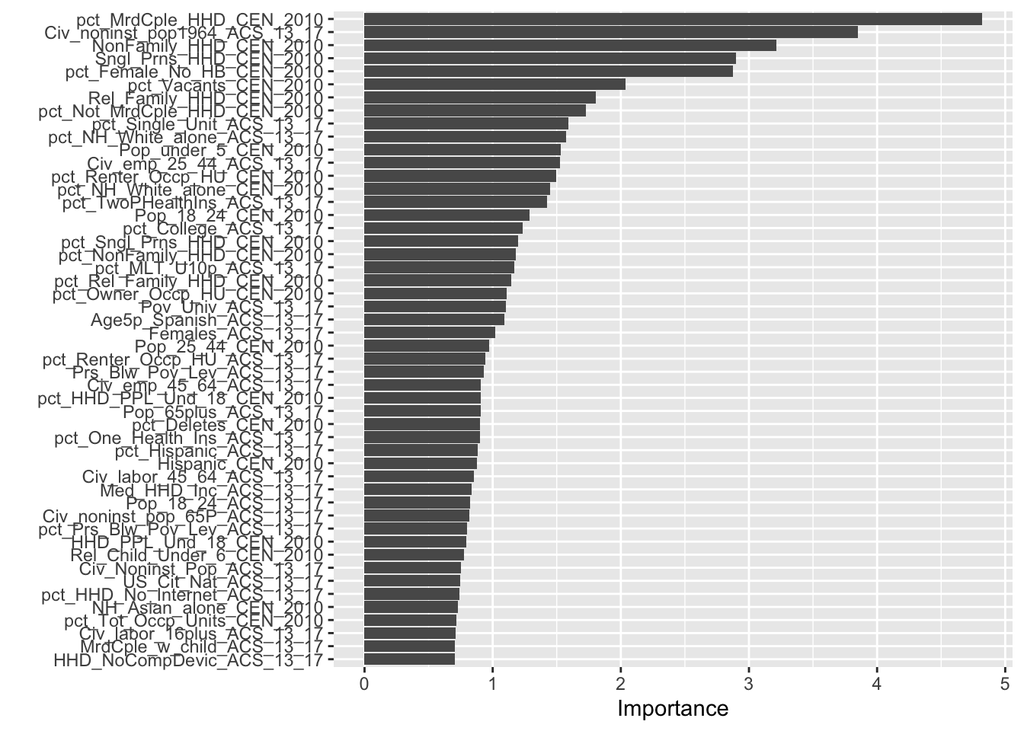

```r
# Variable importance
en_fit <- fit(en_final_wf, data = train_data)

# Save the top 50 variable names
top_50_vars <- en_fit |>
  extract_fit_parsnip() |>
  vi(num_features = 50) |>
  pull(Variable)

# Visualize the plot
en_fit |>
  extract_fit_parsnip() |>
  vip(num_features = 50)
```

All our linear regression models employing feature engineering, selection, and regularization had similar RMSE outcomes. Next, to further improve RMSE, we adopt a more complex model that will be better at learning the non-linear patterns in the data.

## Model 2: Regression tree (Non-parametric)

For our second type of model, we have selected a regression tree, a non-parametric approach. We tune the following three regression tree hyperparameters:

- Cost complexity - balances accuracy with tree size
- Tree depth - the length from the root node to the farthest leaf
- min_n - the minimum number of data points a node must contain before further splitting

After removing “id” variables, character variables, and variables highly similar to the outcome variable, we select only the top 50 most important features from elastic net regression to reduce computational expense.

```r
set.seed(20260414)
tic()
# Recipe
model2_rec <- recipe(non_return_rate ~ ., data = train_data) |>
  # Specify and remove id variables
  update_role(State_name, County_name, new_role = "id") |>
  # Remove highly redundant/correlated variables
  step_rm(has_role("id"),
          # Remove character variables
          Aggr_House_Value_ACS_13_17,
          avg_Agg_HH_INC_ACS_13_17,
          avg_Agg_House_Value_ACS_13_17,
          # Remove variables similar to the outcome variable
          Low_Response_Score,
          Self_Response_Rate_ACS_13_17) |>
  # Select the top 50 most important features from elastic net
  step_select(all_of(top_50_vars), non_return_rate) |>
  # Impute median for missingness
  step_impute_median(all_numeric_predictors())
# Model
model2_mod <- decision_tree(
    cost_complexity = tune(),
    tree_depth = tune(),
    min_n = tune()
  ) |>
  set_engine(engine = "rpart") |>
  set_mode(mode = "regression")

# Tuning grid
model2_grid <- grid_space_filling(
  cost_complexity(range = c(-5, -1)),
  tree_depth(range = c(3, 15)),
  min_n(range = c(2, 50)),
  size = 20
)

# Workflow
model2_wf <-
  workflow() |>
  add_recipe(recipe = model2_rec) |>
  add_model(spec = model2_mod)

# Resamples
model2_resamples <- model2_wf |>
  tune_grid(resamples = folds,
            grid = model2_grid,
            metrics = metric_set(rmse),
            control = control_grid(parallel_over = "everything"))

# Collect metrics
collect_metrics(model2_resamples)
```

```
# A tibble: 20 × 9
   cost_complexity tree_depth min_n .metric .estimator  mean     n std_err
             <dbl>      <int> <int> <chr>   <chr>      <dbl> <int>   <dbl>
 1       0.00001            9    19 rmse    standard    5.12     5  0.0697
 2       0.0000162          5    29 rmse    standard    5.27     5  0.0590
 3       0.0000264         11    37 rmse    standard    5.08     5  0.0811
 4       0.0000428          5     9 rmse    standard    5.32     5  0.0555
 5       0.0000695          7    47 rmse    standard    5.01     5  0.0708
 6       0.000113           9     4 rmse    standard    5.29     5  0.0742
 7       0.000183          15    22 rmse    standard    5.11     5  0.0512
 8       0.000298           4    42 rmse    standard    5.38     5  0.0808
 9       0.000483           3    17 rmse    standard    5.69     5  0.0817
10       0.000785           8    27 rmse    standard    5.16     5  0.0666
11       0.00127           13    44 rmse    standard    5.13     5  0.0746
12       0.00207            6     2 rmse    standard    5.34     5  0.0688
13       0.00336           12     7 rmse    standard    5.35     5  0.0669
14       0.00546            7    50 rmse    standard    5.43     5  0.0902
15       0.00886            3    34 rmse    standard    5.69     5  0.0817
16       0.0144            14    24 rmse    standard    5.68     5  0.0903
17       0.0234             4    14 rmse    standard    5.82     5  0.0831
18       0.0379            10    39 rmse    standard    6.02     5  0.0721
19       0.0616             8    12 rmse    standard    6.68     5  0.0758
20       0.1                6    32 rmse    standard    6.68     5  0.0758
# ℹ 1 more variable: .config <chr>
```

```r
toc()
```

```
1640.714 sec elapsed
```

```r
model2_resamples |>
  show_best()
```

```
# A tibble: 5 × 9
  cost_complexity tree_depth min_n .metric .estimator  mean     n std_err
            <dbl>      <int> <int> <chr>   <chr>      <dbl> <int>   <dbl>
1       0.0000695          7    47 rmse    standard    5.01     5  0.0708
2       0.0000264         11    37 rmse    standard    5.08     5  0.0811
3       0.000183          15    22 rmse    standard    5.11     5  0.0512
4       0.00001            9    19 rmse    standard    5.12     5  0.0697
5       0.00127           13    44 rmse    standard    5.13     5  0.0746
# ℹ 1 more variable: .config <chr>
```

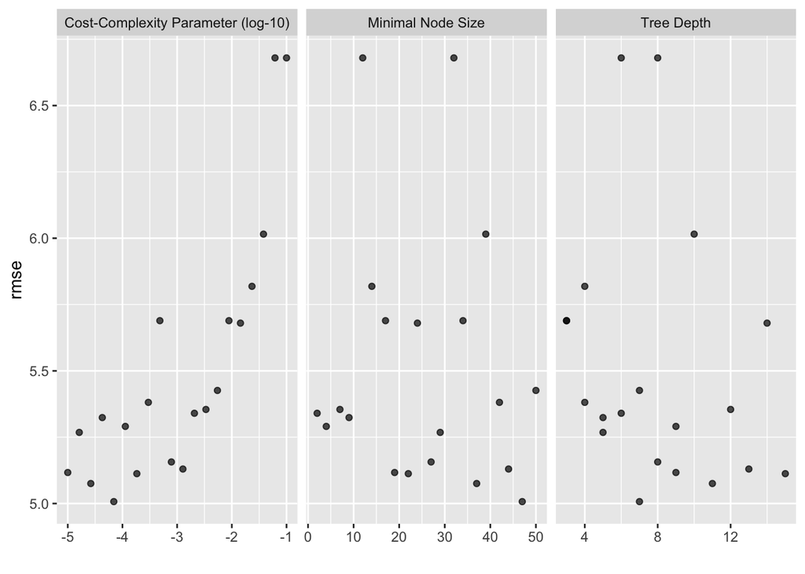

```r
# Visualize the results
autoplot(model2_resamples)
```

Our regression tree RMSE is not better than what we achieved using various linear regressions.

In the top results, the tree depth varies widely, the cost complexity is very small, and the min_n is moderately large. These results suggest that the tree depth doesn’t matter very much, but smaller cost complexity and splitting on moderate/large nodes are best. Rather than tweaking our regression tree model to improve RMSE, we will attempt ensembling methods to improve out-of-sample performance.